# Cross-Validation

Daniel Bohorquez, Jason Heiserman, Mary Tarabocchia

November 2022

# What is Cross-Validation?

- Technique used to assess the performance (accuracy) of a machine learning model
- Involves reserving a sample of your data set for testing
- The goal is to gain insight on how the model will generalize to an unknown data set
- Easy to understand and implement
- Beneficial when the amount of data available is limited

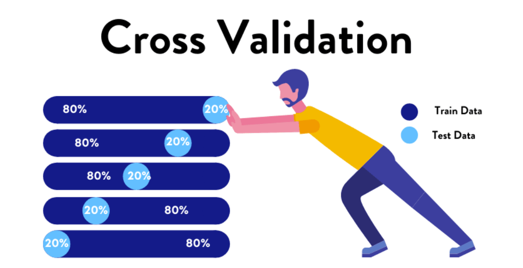

# Overfitting and Underfitting

Overfitting occurs when the model finds patterns in the training data that are caused by random chance.

Underfitting occurs when the model cannot “learn” the underlying trend of the data

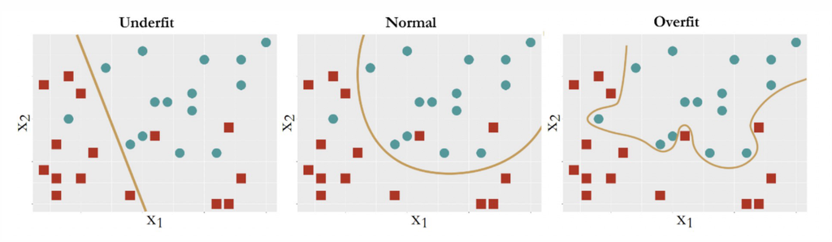

# KFold Cross-Validation

How does it work?

- Data set is divided into k parts
- With each iteration, the model is trained on the k-1 subsets of the entire data set and tested on the kth subset
- The average error across all k trials is computed in order to find the best model

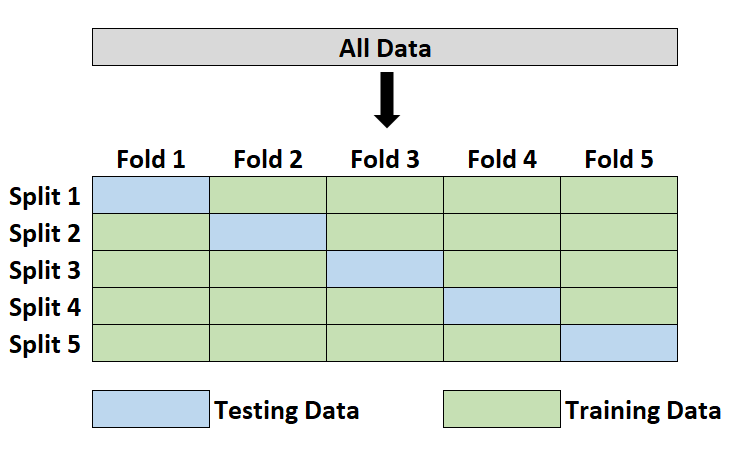

# KFold Cross-Validation (continued)

Pros and Cons

- Produces less biased models as every data point from the original data set will appear in both the training and testing set.
- Optimal if you have a limited amount of data
- Time-consuming because the algorithm has to rerun k times

# Holdout Cross-Validation

What is it? How does it work?

- Original data set is split in the ratio of 80:20 or 70:30
- Data is randomly shuffled before it is split
- High variance if training data set is not representative of the entire data set
- Ideal if you’re in a hurry to train and test a model and have a large data set

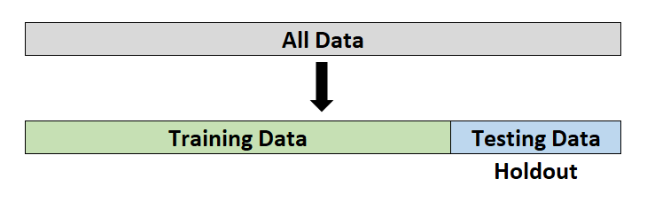

# Leave-One-Out Cross-Validation

How does it work?

- Test data set contains only one element from the original data set
- Training data set consists in all the remaining elements from the original data set

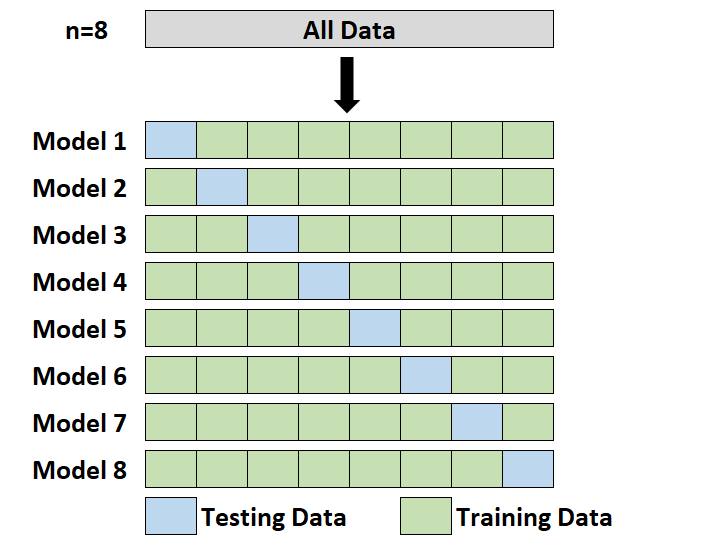

# Leave-One-Out Cross-Validation (continued)

Pros and Cons

- Can be very time-consuming depending on size of data set
- May result in better models since this method uses the largest amount of samples available for training
- No need to shuffle the data, since all possible combinations of train/test data sets will be generated

# Other CV Methods

**Stratified KFold Cross-Validation**

- With straight KFold cross-validation, there’s a chance that we end up with an imbalanced subset
- Can cause the training to be biased, which results in inaccurate models
- In stratification, the data is rearranged to ensure that each subset is a good representation of the entire data set.

**Leave-P-Out Cross-Validation**

- The model is trained on n-p data points and tested on p data points
- The same process is repeated for all possible combinations of p from the original data
- Results of each iteration are averaged to determine accuracy

# Other CV Methods (continued)

**Monte Carlo Cross-Validation**

- Also known as Repeated random sub-sampling validation
- Training and testing data are determined through a series of random splits
- For each split, the model is fit to the training data, and predictive accuracy is assessed using the testing data.
- The results are then averaged over the splits to determine accuracy
- Some observations may never be selected for the testing subsample, whereas others may be selected more than once

# Example of KFold - R Code

```r
## This sets the cross-validation method with k=5 folds
method <- trainControl(method = "cv", number = 5)

## Fit regression model and use k-fold CV to evaluate performance
crossmodelfull <- train(as.factor(htn) ~ age + bmi + ecghr,
                        data = crossdata,
                        method = "glm",
                        trControl = method)
```

- Jackson Heart data
- Predict htn using age, bmi and ecghr
- Split data into 5 folds
- Test one fold against others

# Example of KFold - Results

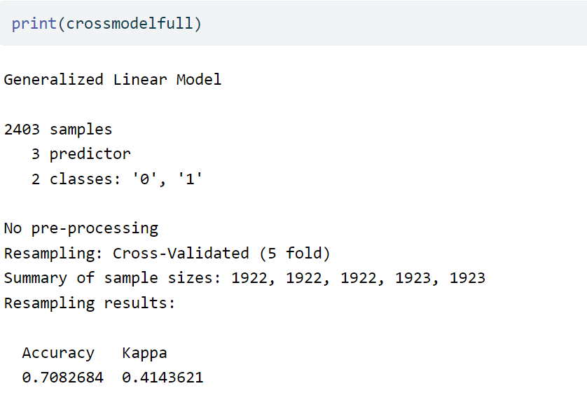

# Conclusion

- Cross-validation can be used to compare the performances of different predictive modeling procedures
  - Example: Optical Character Recognition
  - Which method works best? Support Vector Machine (SVM) or K-Nearest Neighbors (KNN)?
  - Use cross-validation to objectively compare the two methods
- Cross-validation can also be used in variable selection
  - Example: Cancer Research
  - Determine which subset of features should be used to produce the best predictive model

# Questions

[figure not shown]